# Univariate state-space models

22 February 2023

## Topics

Univariate state-space models

1. state (process) model
2. observation model

Simple models of population dynamics

## State-space models

Consist of 2 parts

## Part 1: State model

Describes the **true state of nature** over time

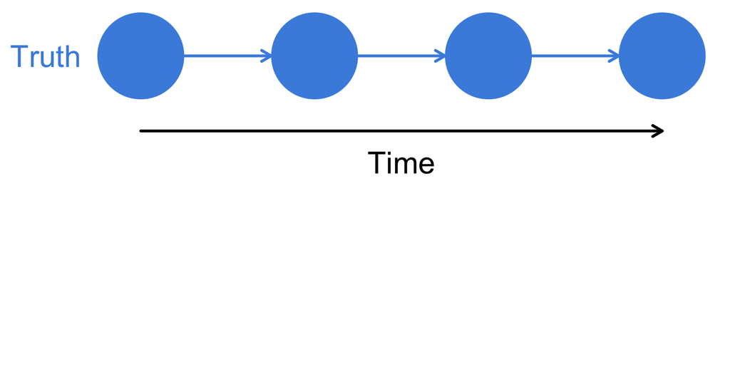

## Part 1: State model

States of nature might be:

- animal’s location
- density of organisms
- reproductive state

## Changes in the state of nature

We can think of changes in the state of nature being driven by a combination of

- intrinsic (eg, fecundity), and
- extrinsic factors (eg, temperature)

## Process errors

Some of the extrinsic drivers may be unknown

In time series modeling, we often call these unknown extrinsic factors *process errors*

## Observation (sampling) errors

Consider for a moment the very act of collecting data

Information gathered depends on many factors

- Environmental conditions (eg, turbidity, currents)
- Behavior (eg, vertical migration, threat avoidance)
- Demographics (age, sex, maturity)
- Sampling design/coverage

## Part 2: Observation model

**Data = Truth + Error**

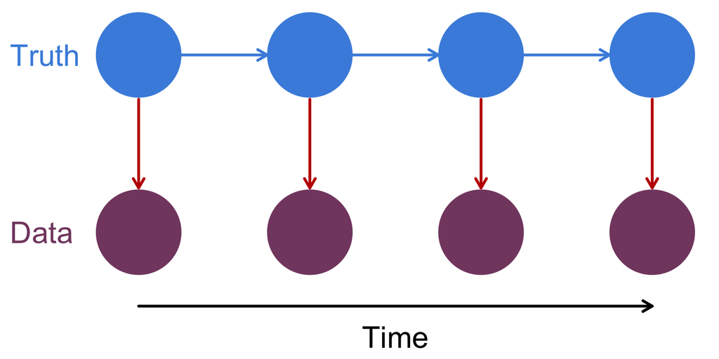

## Consider these data

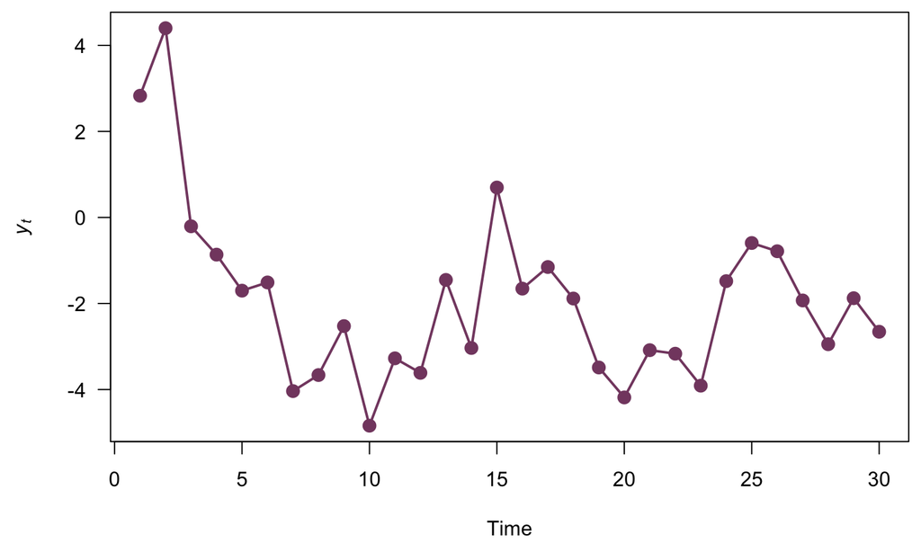

## Model options

### Linear regression

State model

\(x_t = \alpha - \beta t\)

Observation model

\(y_t = x_t + v_t ~ \text{with} ~ v_t \sim \text{N}(0,r)\)

## Linear regression fitted values

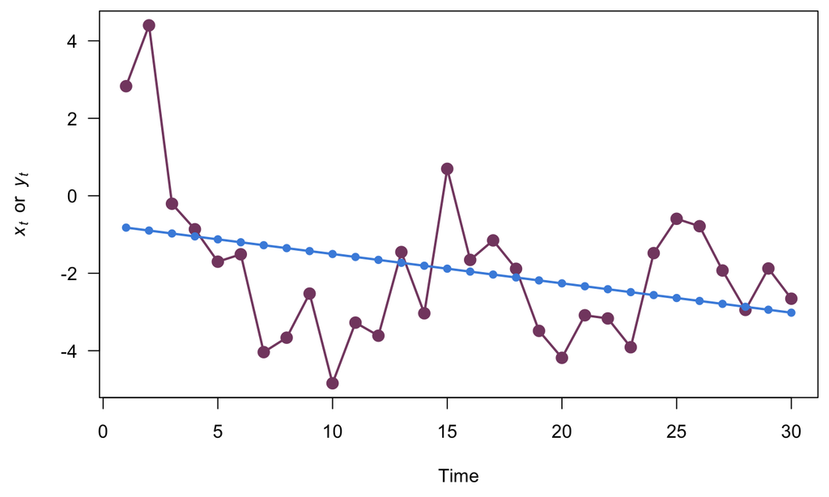

## Observation errors

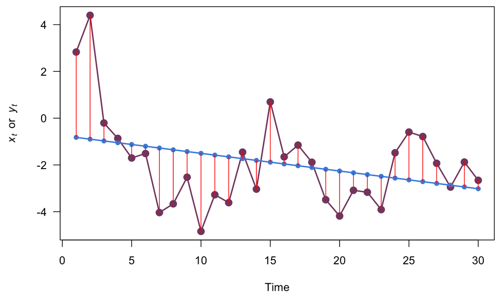

## Model options

### Biased random walk

State model

\(x_t = x_{t-1} + u + w_t ~ \text{with} ~ w_t \sim \text{N}(0,q)\)

Observation model

\(y_t = x_t\)

## Biased random walk

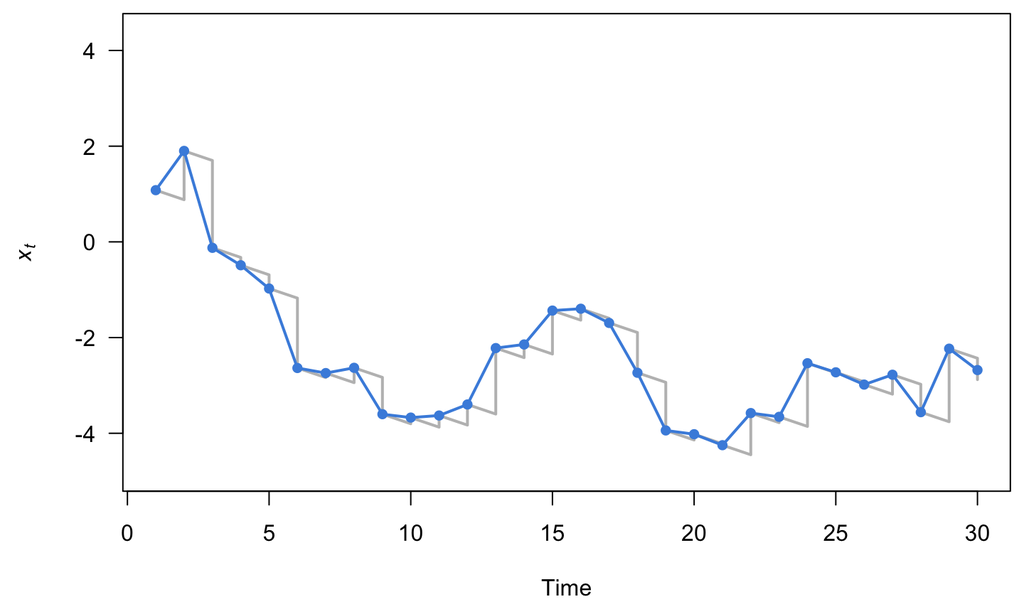

## Examples of biased random walks

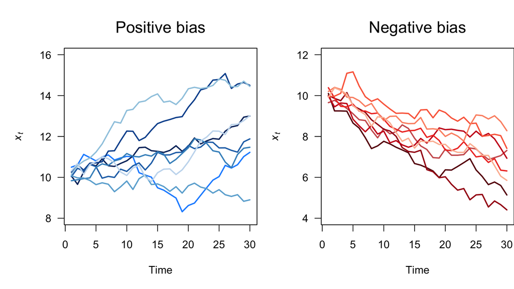

## Biased random walk fit to earlier data

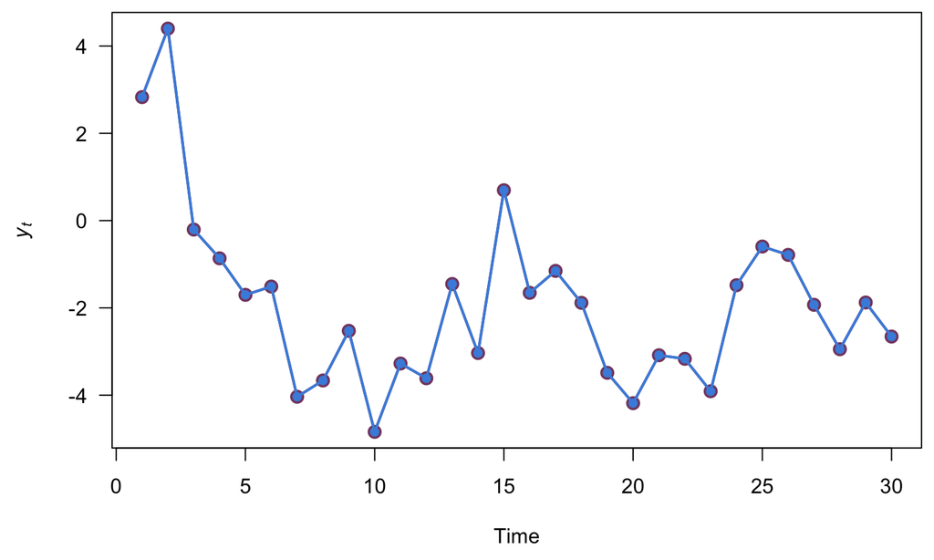

## Process errors

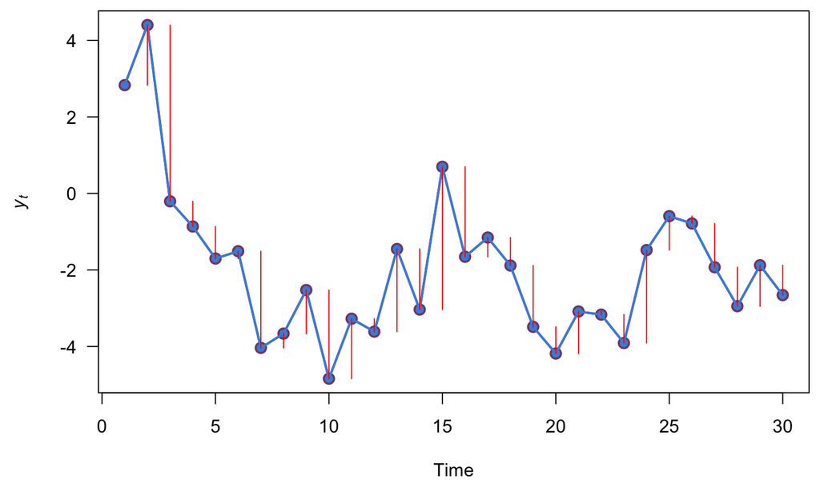

## Model options

### Biased random walk with observation error

State model

\[ x_t = x_{t-1} + u + w_t ~ \text{with} ~ w_t \sim \text{N}(0,q) \]

Observation model

\[ y_t = x_t + v_t ~ \text{with} ~ v_t \sim \text{N}(0,r) \]

## Biased random walk

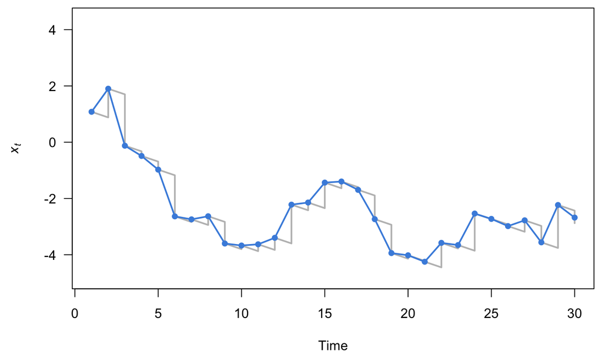

## Biased random walk

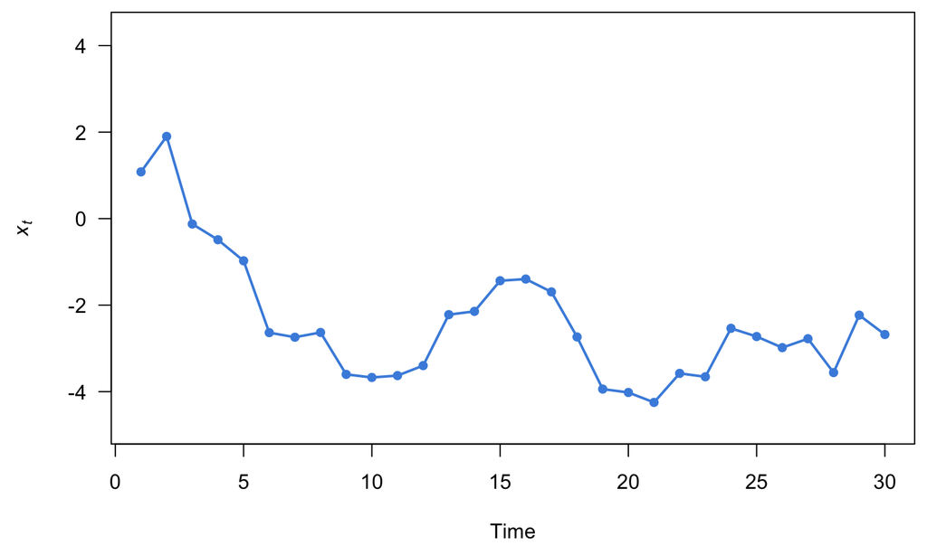

## Biased random walk with obs error

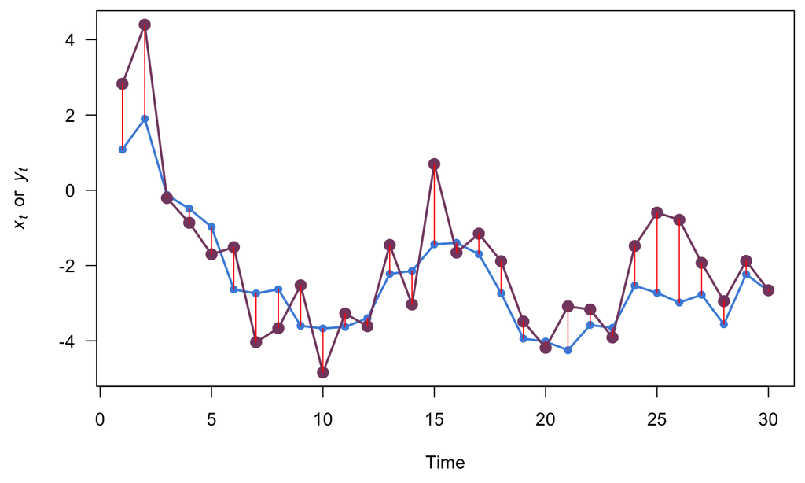

## Biased random walk with obs error

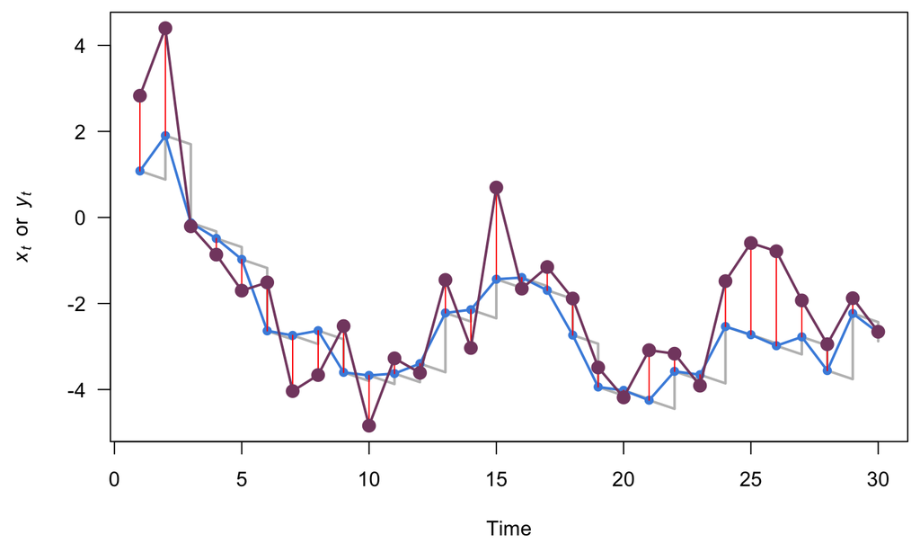

The variance in \(y_t\) is due to both process & observation error

## Separating process & obs errors

How is it possible to separate out both the process and observation errors?

They have different temporal patterns

## Separating process & obs errors

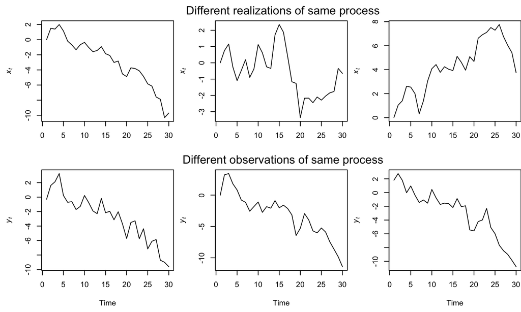

## Population growth

### Density independent

## Density-independent popn growth

### Exponential growth/decline in continuous time

\[ N(t) = N_0 ~ \underbrace{\exp(u)}_{\substack{\text{rate of} \\ \text{change}}} \underbrace{\exp(w t)}_{\substack{\text{stochastic} \\ \text{environment}}} \]

## Density-independent popn growth

### In discrete time, with a time step of 1 year

\[ N_t = N_{t-1} \exp(u + w_t) \]

## Density-independent popn growth

### In discrete time, with a time step of 1 year

\[ N_t = N_{t-1} \exp(u + w_t) \]

Taking the log of both sides and substituting \(x_t\) for \(\log(N_t)\)

\[ \log (N_t) = \log (N_{t-1}) + u + w_t \\ \Downarrow \\ x_t = x_{t-1} + u + w_t \]

## Density-independent popn growth

### Biased random walk

If we assume that the errors are white noise

\[ w_t \sim \text{N}(0, q) \]

then our model of populations dynamics

\[ x_t = x_{t-1} + u + w_t \]

is a biased random walk

## Simulate a biased random walk

```r
## number of time steps
TT <- 40
## bias term
uu <- 0.2
## time series of process errors with var = 1
ww <- rnorm(TT, 0, sqrt(1))
## initialize state & set x0 = w0
xx <- ww
## loop over time steps
for(t in 2:TT) {
  xx[t] <- uu + xx[t-1] + ww[t]
}
```

## Simulate a biased random walk

Add some observation error

```r
## obs errors with var = 0.3
vv <- rnorm(TT, 0, sqrt(0.3))
## obs data
yy <- xx + vv
```

## Log-population size over time

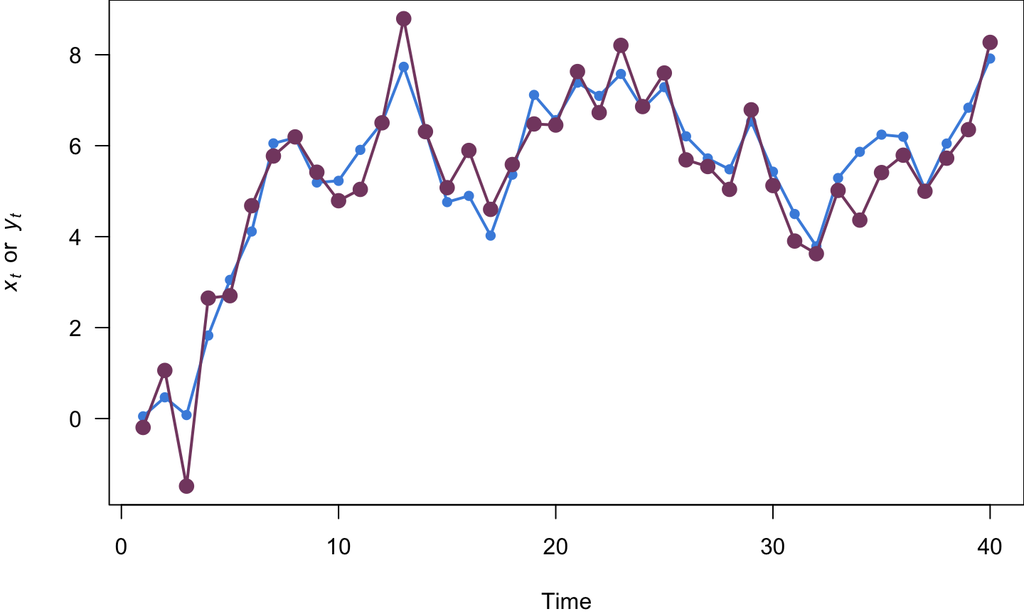

## Fitting models

## Fitting models with `MARSS()`

We can use the **{MARSS}** pkg for R to fit state-space models

To do so, we must write the model out just as we would on a white board

## Fitting models with `MARSS()`

Here are the main function arguments

```r
MARSS(y, model = NULL, inits = NULL, control = NULL, ...)
```

- `y` is an \(n \times T\) `matrix` of data (observations)
- `model` a `list` that defines the state-space model in terms of parameters to be estimated
- `inits` [*optional*] a `list` of initial values for parameters to be estimated
- `control` [*optional*] a `list` of options for controlling fitting algorithms, setting tolerance & convergence parameters, etc

## Fitting models with `MARSS()`

`MARSS()` uses an expanded form of state-space model, such that our biased random walk

\[ \begin{align} x_t &= x_{t-1} + u + w_t \\ y_t &= x_t + v_t \end{align} \] instead becomes

\[ \begin{align} x_t &= b x_{t-1} + u + w_t \\ y_t &= Z x_t + a + v_t \end{align} \]

with \(b = 1\), \(Z = 1\), and \(a = 0\)

## Fitting models with `MARSS()`

State model  
\(x_t = b x_{t-1} + u + w_t ~~ \text{with} ~~ w_t \sim \text{N}(0,q)\)

Observation model  
\(y_t = Z x_t + a + v_t ~~ \text{with} ~~ v_t \sim \text{N}(0,r)\)

```r
mod_list <- list(
  ## state model
  B = matrix(1), U = matrix("u"), Q = matrix("q"),
  ## obs model
  Z = matrix(1), A = matrix(0), R = matrix("r")
  )
```

**Note**: `MARSS()` works with the `matrix` class in **R**, so we have to define any scalar as a \(1 \times 1\) matrix

## Fitting models with `MARSS()`

What about the initial state \(x_0\)?

\[ x_0 \sim \text{N}(\pi,\lambda) \]

Estimating both \(\pi\) and \(\lambda\) is nearly impossible, so the default is to treat \(x_0\) as fixed, but unknown, effect rather than as a random effect, such that

\[ x_0 \sim \text{N}(\pi,0) \]

`MARSS()` will do this for us

## Fitting models with `MARSS()`

We can ignore the `inits` and `control` arguments for now and fit the model

```r
## load MARSS package
library(MARSS)
## define the data as an N (rows) x T (cols) matrix
dat <- matrix(yy, nrow = 1, ncol = TT)
## fit the model
mod_fit <- MARSS(y = dat, model = mod_list)
```

## Fitting models with `MARSS()`

```
## Success! abstol and log-log tests passed at 18 iterations.
## Alert: conv.test.slope.tol is 0.5.
## Test with smaller values (<0.1) to ensure convergence.
##
## MARSS fit is
## Estimation method: kem
## Convergence test: conv.test.slope.tol = 0.5, abstol = 0.001
## Estimation converged in 18 iterations.
## Log-likelihood: -67.76398
## AIC: 143.528   AICc: 144.6708
##
##       Estimate
## R.r      0.531
## U.u      0.198
## Q.q      0.847
## x0.x0   -0.210
## Initial states (x0) defined at t=0
##
## Standard errors have not been calculated.
## Use MARSSparamCIs to compute CIs and bias estimates.
```

## A note on model fitting

When we have 2+ observations of process, our estimates of model parameters are much more accurate and precise.

\[ \begin{align} x_t &= x_{t-1} + u + w_t ~~ \text{with} ~ w_t \sim \text{N}(0,q) \\ ~ \\ \begin{bmatrix} y_1 \\ y_2 \\ \vdots \\ y_n \end{bmatrix}_t &= \begin{bmatrix} 1 \\ 1 \\ \vdots \\ 1 \end{bmatrix} x_t + \begin{bmatrix} v_1 \\ v_2 \\ \vdots \\ v_n \end{bmatrix}_t ~~ \text{with} ~ \mathbf{v_t} \sim \text{MVN}(\mathbf{0},\mathbf{R}) \end{align} \]

## Extracting fitted model objects

Fitted values are stored in an \(N \times T\) matrix (here \(N = 1\)) accessed with `$states`

Standard errors of fitted values are stored in an \(N \times T\) matrix (vector) accessed with `$states.se`

```r
## T x 1 (transposed) vector of states
mod_fits <- t(mod_fit$states)

## T x 1 (transposed) vector of SE's
mod_fits_SE <- t(mod_fit$states.se)
```

## Approximate confidence intervals

We can estimate a \([(1 - \alpha) \times 100]\%\) confidence interval as

\[ \hat{x} ~ \pm ~ t_{1 - \alpha/2} \times \text{SE}(\hat{x}) \]

## Approximate confidence intervals

```r
## upper 95% CI
mod_fits_CI_hi <- mod_fits + qt(p = 0.975, df = TT - 1) * mod_fits_SE

## lower 95% CI
mod_fits_CI_lo <- mod_fits - qt(p = 0.975, df = TT - 1) * mod_fits_SE
```

## Model fit and true states

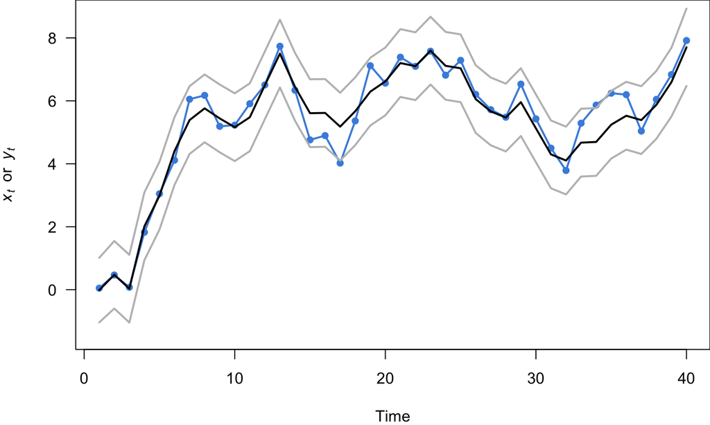

## Model fit with observations only

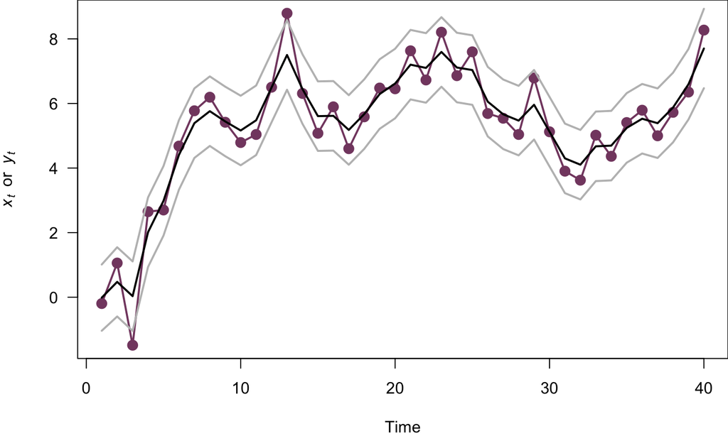